# Exam 1

## Exam 1

#### Metainformation

1. | Tag | Value |
   | --- | --- |
   | `file` | Inferential_Statistics_vufsw-moderation-0115-nl_vufsw-moderation-0115-nl |
   | `name` | vufsw-moderation-0115-nl |
   | `section` | inferential statistics/regression/multiple linear regression/moderation |
   | `type` | schoice |
   | `solution` | TRUE, FALSE, FALSE, FALSE |
   | `Type` | interpretating output |
   | `Program` | calculator |
   | `Language` | dutch |
   | `Level` | statistical literacy |

#### Question

   Hieronder staat de resultaten van een stapsgewijze regressie-analyse. De afhankelijke variabele “**Rapportcijfer_politie**” is iemands vertrouwen in de politie gemeten op een schaal die loopt van 1 (heel weinig vertrouwen) t/m 10 (heel veel vertrouwen). “**Migratieachtergrond** (1 = ja, 0 = nee) is een dummy variabele die aangeeft op iemand een migratieachtergrond heeft.”**Politie_naar_respondent**“ is een dummy variabele die aangeeft of iemand het afgelopen jaar contact had met de politie omdat de politie naar hem/haar toekwam (score = 1) of iemand daarentegen geen contact had of iemand zelf naar de politie toeging (score = 0). Tot slot is”**Politie_naar_respondent_Migratieachtergrond**" een multiplicatieve interactie-term van de variabelen Migratieachtergrond en Politie_naar_respondent.

   Bestudeer het regressiemodel met de interactie-term (Model 2).

   Stel, we vergelijken twee personen **zonder** een migratieachtergrond met elkaar, Donny en Klaas Jan. Donny heeft afgelopen jaar contact gehad met de politie omdat de politie naar hem toe kwam; Klaas Jan had het afgelopen jaar *geen* contact met de politie. Hoeveel lager is het geschatte vertrouwen in de politie van Donny in vergelijking met Klaas Jan?

   En stel dat we nu twee personen **met** een migratieachtergrond met elkaar vergelijken, Dušan en Hakim. Dušan heeft afgelopen jaar contact gehad met de politie omdat de politie naar hem toe kwam; Hakim had het afgelopen jaar *geen* contact met de politie. Hoeveel lager is het geschatte vertrouwen in de politie van Dušan in vergelijking met Hakim?

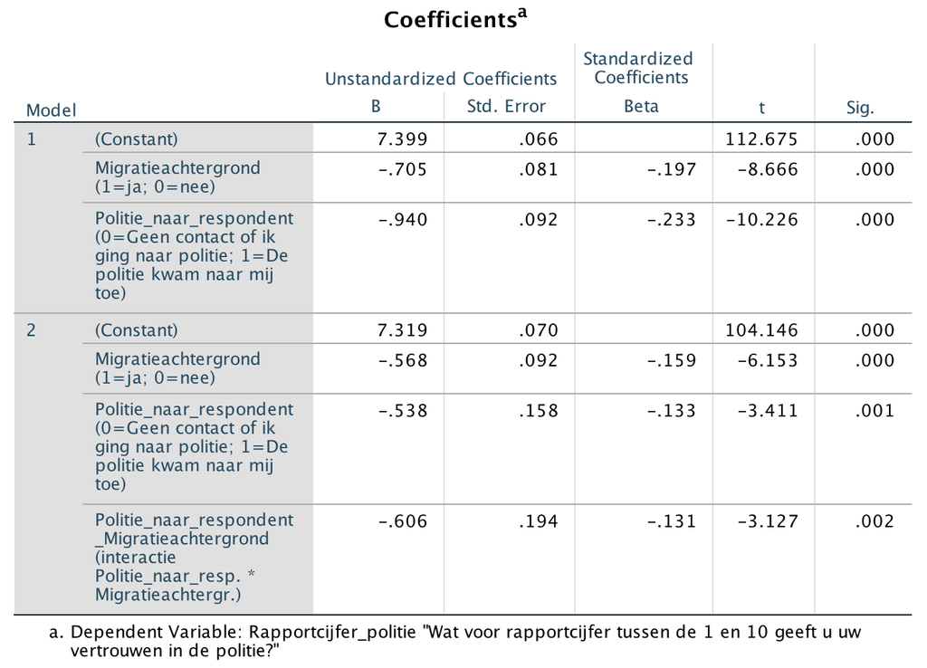

   1. **TRUE:** Donny heeft **0,538***minder* vertrouwen in de politie dan Klaas Jan. En Dušan heeft **1,144** (0,538 + 0,606) *minder* vertrouwen in de politie dan Hakim.
   2. **FALSE:** Donny heeft **0,068** (0,606 – 0,538) *minder* vertrouwen in de politie dan Klaas Jan. En Dušan heeft **0,606***minder* vertrouwen in de politie dan Hakim.
   3. **FALSE:** Donny heeft **1,144** (0,606 + 0,538) *minder* vertrouwen in de politie dan Klaas Jan. En Dušan heeft **0,606***minder* vertrouwen in de politie dan Hakim.
   4. **FALSE:** Donny heeft **0,606***minder* vertrouwen in de politie dan Klaas Jan. En Dušan heeft **1,144** (0,538 + 0,606) *minder* vertrouwen in de politie dan Hakim.

#### Solution

   Language  
   Nederlands

   Levels of Difficulty  
   Easy

   M&T Basics of quantitative research  
   Basics of quantitative research

   M&T BIS  
   Default value
   1. True
   2. False
   3. False
   4. False